# Physics 21, Spring 2020

## Assignment 4a: Bayesian Analysis

```python
from matplotlib import pyplot as pl
import numpy as np
from math import factorial
import copy
```

# Part 1

We first write the coin tossing function `tossNCoins`, and the likelihood function `pDgivenH`.

```python
def tossNCoins(H, n):
    return np.random.choice(['H', 'T'], size = n, p = [H, 1-H])

def pDgivenH(trials, H):
    n = len(trials)
    h = sum(trials == 'H')
    pD = factorial(n) / (factorial(h) * factorial(n-h))
    pD *= H ** h * (1-H) ** (n-h)
    return pD
```

```python
tossNCoins(0.5, 5), pDgivenH(tossNCoins(0.5, 100), 0)
```

```
(array(['H', 'H', 'T', 'T', 'H'], dtype='<U1'), 0.0)
```

## Uniform Prior

```python
gridSize = 1000
dH = 1 / gridSize

Hseq = np.linspace(0, 1, gridSize)
prior = np.ones_like(Hseq) # uniform prior
prior /= (sum(prior) * dH) # normalize
posterior = np.zeros_like(Hseq)
```

```python
sum(prior * dH)
```

```
1.0000000000000007
```

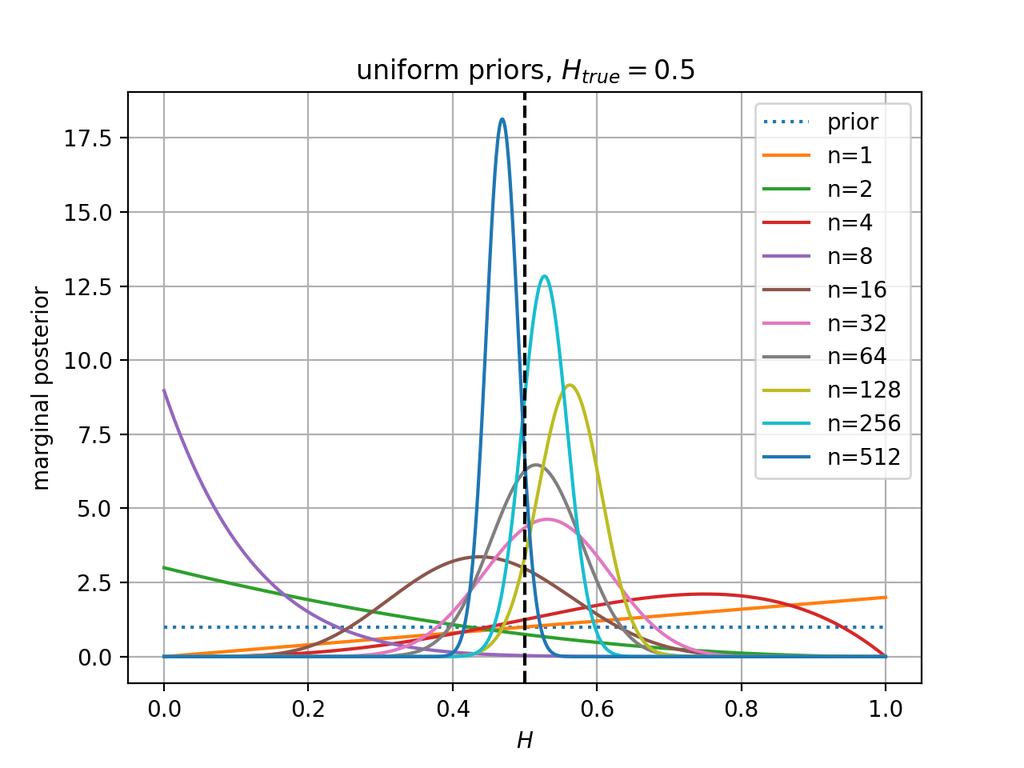

```python
%matplotlib notebook
pl.plot(Hseq, prior, label = "prior", linestyle = ":")
n = 1
Htrue = 0.5
while n <= 512:

    trials = tossNCoins(Htrue, n)

    for i, H in enumerate(Hseq):
        posterior[i] = pDgivenH(trials, H) * prior[i]

    posterior /= (sum(posterior) * dH) # normalize

    pl.plot(Hseq, posterior, label = f"n={n}")
    n *= 2

pl.grid()
pl.legend()
pl.xlabel(r"$H$")
pl.ylabel(r"marginal posterior")
pl.title(r"uniform priors, $H_{true} = 0.5$")
pl.axvline(x = Htrue, linestyle = "--", color = "black")
```

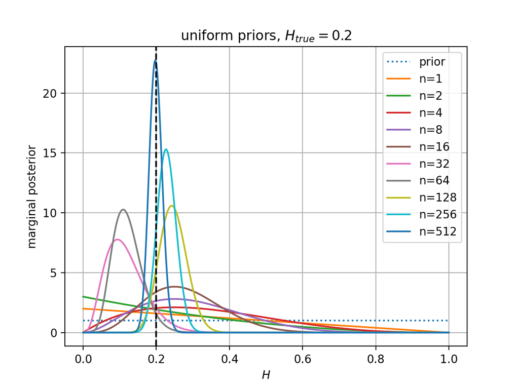

```python
%matplotlib notebook
pl.plot(Hseq, prior, label = "prior", linestyle = ":")
n = 1
Htrue = 0.2
while n <= 512:

    trials = tossNCoins(Htrue, n)

    for i, H in enumerate(Hseq):
        posterior[i] = pDgivenH(trials, H) * prior[i]

    posterior /= (sum(posterior) * dH) # normalize

    pl.plot(Hseq, posterior, label = f"n={n}")
    n *= 2

pl.grid()
pl.legend()
pl.xlabel(r"$H$")
pl.ylabel(r"marginal posterior")
pl.title(r"uniform priors, $H_{true} = 0.2$")
pl.axvline(x = Htrue, linestyle = "--", color = "black")
```

In either case for uniform priors, we note that as $n$ increases, the posterior tends to a narrower Gaussian with mean close to $H_{true}$.

# Gaussian Prior

```python
def gaussian(x, mean, sd):
    return np.exp(-(x - mean) ** 2 / (2 * sd ** 2))
```

```python
gridSize = 1000
dH = 1 / gridSize

meanH, sdH = 0.5, 0.1

Hseq = np.linspace(0, 1, gridSize)
prior = gaussian(Hseq, meanH, sdH) # gaussian prior
prior /= (sum(prior) * dH) # normalize
posterior = np.zeros_like(Hseq)
```

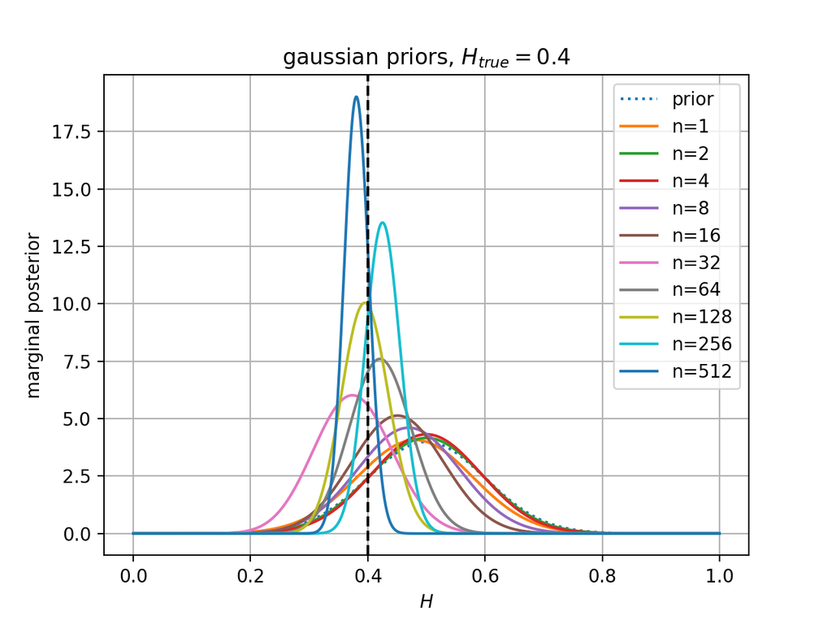

```python
%matplotlib notebook
pl.plot(Hseq, prior, label = "prior", linestyle = ":")
n = 1
Htrue = 0.4
while n <= 512:

    trials = tossNCoins(Htrue, n)

    for i, H in enumerate(Hseq):
        posterior[i] = pDgivenH(trials, H) * prior[i]

    posterior /= (sum(posterior) * dH) # normalize

    pl.plot(Hseq, posterior, label = f"n={n}")
    n *= 2

pl.grid()
pl.legend()
pl.xlabel(r"$H$")
pl.ylabel(r"marginal posterior")
pl.title(r"gaussian priors, $H_{true} = 0.4$")
pl.axvline(x = Htrue, linestyle = "--", color = "black")
```

[figure not shown]

```python
%matplotlib notebook
pl.plot(Hseq, prior, label = "prior", linestyle = ":")
n = 1
Htrue = 0.2
while n <= 512:

    trials = tossNCoins(Htrue, n)

    for i, H in enumerate(Hseq):
        posterior[i] = pDgivenH(trials, H) * prior[i]

    posterior /= (sum(posterior) * dH) # normalize

    pl.plot(Hseq, posterior, label = f"n={n}")
    n *= 2

pl.grid()
pl.legend()
pl.xlabel(r"$H$")
pl.ylabel(r"marginal posterior")
pl.title(r"uniform priors, $H_{true} = 0.2$")
pl.axvline(x = Htrue, linestyle = "--", color = "black")
```

In either case for Gaussian priors, while at the start the distribution is biased towards the prior mean, with a large number of samples ($n$ of the order of a few hundreds), the posterior tends to a narrower Gaussian with mean close to $H_{true}$, just like with uniform priors.

# Part 2

The random variable we deal with is $\theta_k$, which is distributed uniformly. We can write: $$\tan(\theta_k) = \frac{x_k - \alpha}{\beta}$$ $$x_k = \alpha + \beta\tan(\theta_k)$$

Now, as due to normalization $\int p(\theta)d\theta = 1 = \int p(x) dx$. Doing a substitution, $p(\theta) = p(x) \frac{dx}{d\theta}$, or: $$p(x) = p(\theta) \frac{d\theta}{dx} \propto \frac{1}{\beta \sec^2(\theta_k)} = \frac{1}{\beta + \beta \tan^2(\theta_k)} = \frac{1}{\beta + (x-\alpha)^2/ \beta} = \frac{\beta}{\beta^2 + (x-\alpha)^2}$$ We will use this $p(x)$ to get our likelihood function.

```python
def simulateX_k(alpha_true, beta_true, n):
    theta = np.random.random(n) * np.pi - (np.pi / 2)
    return alpha_true + beta_true * np.tan(theta)
```

```python
def log_likelihood(trials, alpha, beta):
    logp = 0
    for x in trials:
        logp += np.log(beta) - np.log(beta ** 2 + (x - alpha) ** 2)
    return logp
```

## $\beta_{true}$ known

```python
gridSize = 1000
dAlpha = 1 / gridSize

alpha_seq = np.linspace(-5, 5, gridSize)
prior = np.ones_like(alpha_seq) # uniform prior
prior /= (sum(prior) * dAlpha) # normalize
posterior = np.zeros_like(alpha_seq)
```

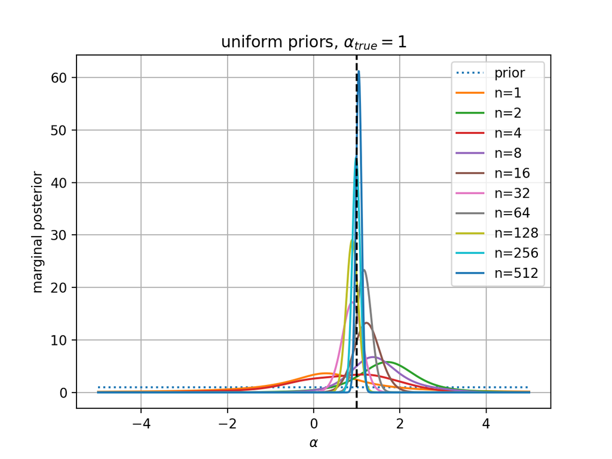

```python
%matplotlib notebook
pl.plot(alpha_seq, prior, label = "prior", linestyle = ":")
n = 1
alpha_true = 1
beta_true = 1
while n <= 512:
    beta = beta_true
    trials = simulateX_k(alpha_true, beta_true, n)

    for i, alpha in enumerate(alpha_seq):
        posterior[i] = np.exp(log_likelihood(trials, alpha, beta)) * prior[i]

    posterior /= (sum(posterior) * dAlpha) # normalize

    pl.plot(alpha_seq, posterior, label = f"n={n}")
    n *= 2

pl.grid()
pl.legend()
pl.xlabel(r"$\alpha$")
pl.ylabel(r"marginal posterior")
pl.title(r"uniform priors, $\alpha_{true} = 1$")
pl.axvline(x = alpha_true, linestyle = "--", color = "black")
```

Using uniform priors and a method similar to Part 1, we can infer $\alpha$ pretty well given $\beta$. We now check how well the mean of data $\bar{x}_k$ works as a predictor for $\alpha$.

```python
mean_Xks = []
for i in range(1000):
    mean_Xks += [np.mean(simulateX_k(alpha_true, beta_true, 512))]
```

```python
np.std(mean_Xks)
```

```
69.33896690966277
```

This standard deviation is very very high, especially for 1000 computations for the mean. To investigate further, we make a histogram of $\bar{x}_k$ after trimming the most extreme values.

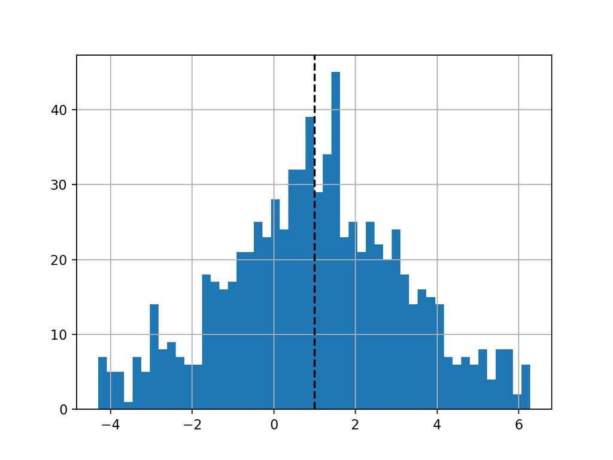

```python
%matplotlib notebook

mean_Xks.sort()

pl.hist(mean_Xks[100:-100], bins=50)
pl.grid()
pl.axvline(x = alpha_true, linestyle = "--", color = "black")
```

Even after removing 20\% of the 1000 means, we see that the scatter in the $\bar{x}_k$ is significant almost over the entire working range of $\alpha$. So, $\bar{x}_k$ is a poor predictor for $\alpha$.

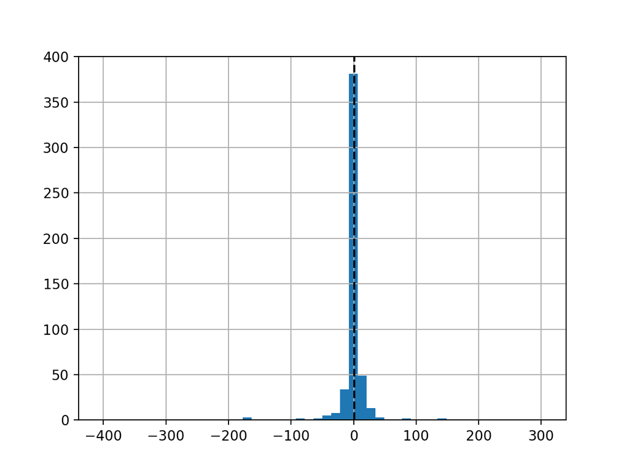

```python
%matplotlib notebook
pl.hist(simulateX_k(alpha_true, beta_true, 512), bins=50)
pl.grid()
pl.axvline(x = alpha_true, linestyle = "--", color = "black")
```

A much better predictor for $\alpha_k$ is the median of the random samples $x_k$ as shown below. The scatter about $\alpha_{true}$ is minimal for all of the values.

```python
median_Xks = []
for i in range(1000):
    median_Xks += [np.median(simulateX_k(alpha_true, beta_true, 512))]
np.std(median_Xks)
```

```
0.13679313219300956
```

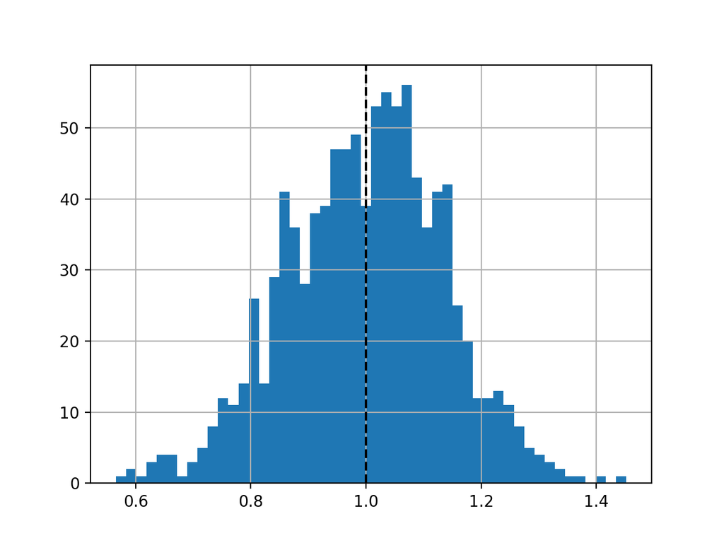

```python
%matplotlib notebook

pl.hist(median_Xks, bins=50)
pl.grid()
pl.axvline(x = alpha_true, linestyle = "--", color = "black")
```

## $\beta_{true}$ unknown

```python
gridSize = 50
dAlpha = 1 / gridSize
dBeta = 1 / gridSize

alpha_seq = np.linspace(0, 4, gridSize)
beta_seq = np.linspace(0.0001, 4, gridSize)
logprior = 0 # uniform prior
logposterior = np.zeros((len(alpha_seq), len(beta_seq)))
posterior = np.zeros((len(alpha_seq), len(beta_seq)))
```

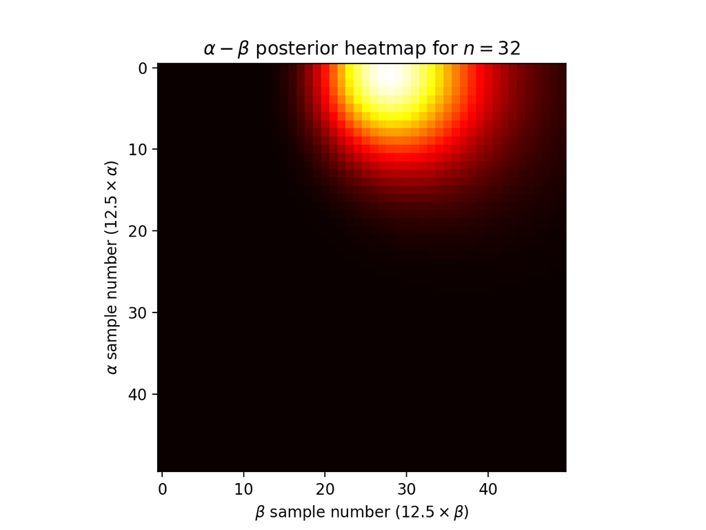

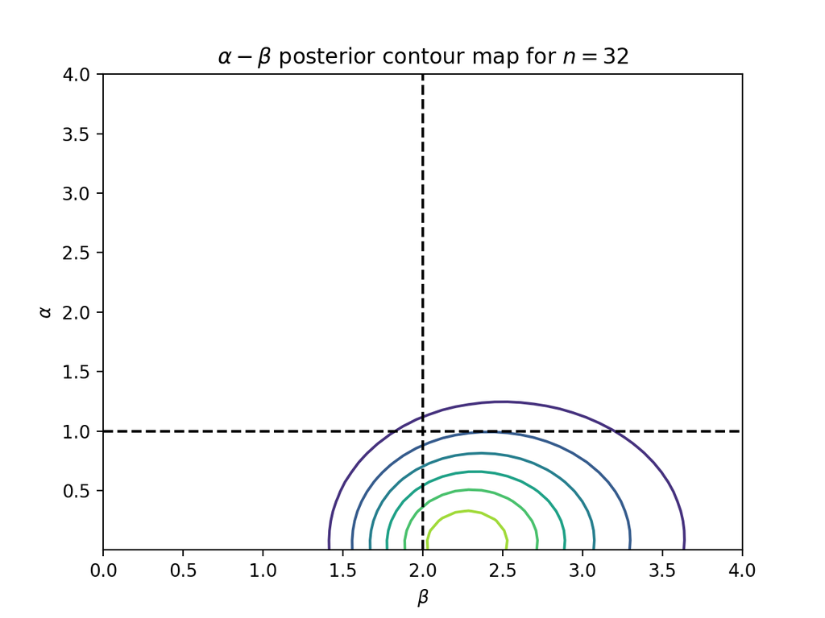

```python
%matplotlib notebook

n = 32
alpha_true = 1
beta_true = 2

trials = simulateX_k(alpha_true, beta_true, n)

for i, alpha in enumerate(alpha_seq):
    for j, beta in enumerate(beta_seq):
        logposterior[i, j] = log_likelihood(trials, alpha, beta) + logprior

logposterior -= np.max(logposterior)
posterior = np.exp(logposterior)

pl.figure(1)
pl.title(r'$\alpha-\beta$ posterior heatmap for $n=32$')
pl.ylabel(r'$\alpha$ sample number ($12.5 \times \alpha$)')
pl.xlabel(r'$\beta$ sample number ($12.5 \times \beta$)')
pl.imshow(posterior, cmap='hot', interpolation='nearest')

pl.figure(2)
pl.title(r'$\alpha-\beta$ posterior contour map for $n=32$')
pl.ylabel(r'$\alpha$')
pl.xlabel(r'$\beta$')
pl.contour(alpha_seq, beta_seq, posterior)
pl.axvline(x = beta_true, linestyle = "--", color = "black")
pl.axhline(y = alpha_true, linestyle = "--", color = "black")
```

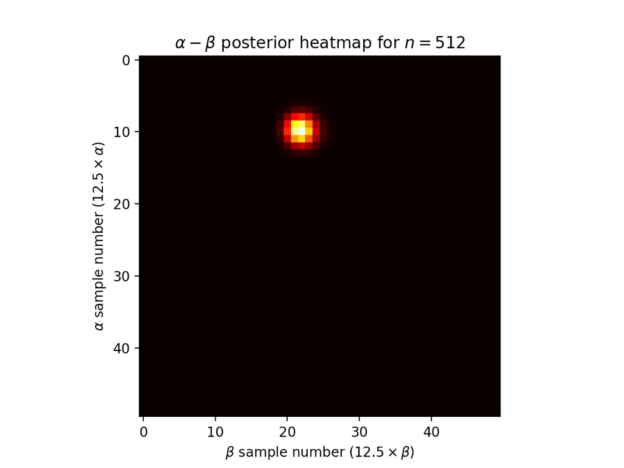

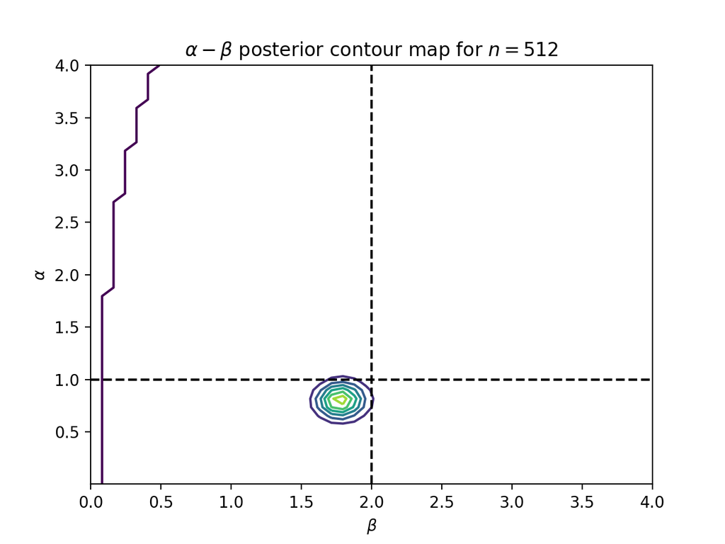

```python
%matplotlib notebook

n = 512
alpha_true = 1
beta_true = 2

trials = simulateX_k(alpha_true, beta_true, n)

for i, alpha in enumerate(alpha_seq):
    for j, beta in enumerate(beta_seq):
        logposterior[i, j] = log_likelihood(trials, alpha, beta) + logprior

logposterior -= np.max(logposterior)
posterior = np.exp(logposterior)

pl.figure(1)
pl.title(r'$\alpha-\beta$ posterior heatmap for $n=512$')
pl.ylabel(r'$\alpha$ sample number ($12.5 \times \alpha$)')
pl.xlabel(r'$\beta$ sample number ($12.5 \times \beta$)')
pl.imshow(posterior, cmap='hot', interpolation='nearest')

pl.figure(2)
pl.title(r'$\alpha-\beta$ posterior contour map for $n=512$')
pl.ylabel(r'$\alpha$')
pl.xlabel(r'$\beta$')
pl.contour(alpha_seq, beta_seq, posterior)
pl.axvline(x = beta_true, linestyle = "--", color = "black")
pl.axhline(y = alpha_true, linestyle = "--", color = "black")
```

We seem to be able to infer both $\alpha$ and $\beta$ for a larger sample size ~512.